# PYTHON DATA VISUALIZATION WITH MATPLOT_LIB

# Pie Chart

Pie charts are typically used to show percentage or proportional data. Usually, the percentage represented by each category is provided next to the corresponding slice of the pie. matplotlib provides the pie method to make pie charts. It has several advantages:

1. It summarizes a large data set in visual form.
2. It displays the relative proportions of multiple classes of data.
3. The size of the circle is made proportional to the total quantity.

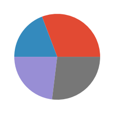

```python
#plot simple pie chart
book = ['julia','datascienc','os','security']
quintity=[8000,5000,6000,7000]
plt.pie(quintity)
plt.show()
```

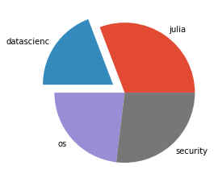

```python
# slice the chart
book = ['julia','datascienc','os','security']
quintity=[8000,5000,6000,7000]
exploade = [0,0.2,0,0]
plt.pie(quintity ,labels=book,explode=exploade )
plt.show()
```

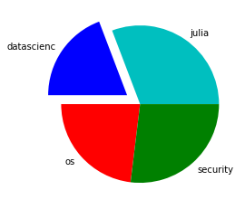

```python
#use the color of chart your own
book = ['julia','datascienc','os','security']
quintity=[8000,5000,6000,7000]
exploade = [0,0.2,0,0]
colors =['c','b','r','g']
plt.pie(quintity ,labels=book,explode=exploade,colors=colors )
plt.show()
```

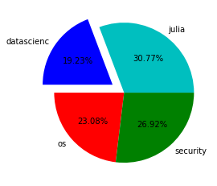

```python
#show the presentage of the chart
book = ['julia','datascienc','os','security']
quintity=[8000,5000,6000,7000]
exploade = [0,0.2,0,0]
colors =['c','b','r','g']
plt.pie(quintity ,labels=book,explode=exploade,colors=colors,autopct ="%0.2f%%" )
plt.show()
```

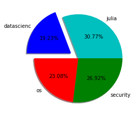

```python
#show the shadow of the chart
book = ['julia','datascienc','os','security']
quintity=[8000,5000,6000,7000]
exploade = [0,0.2,0,0]
colors =['c','b','r','g']
plt.pie(quintity ,labels=book,explode=exploade,colors=colors,autopct ="%0.2f%%",shadow=True )
plt.show()
```

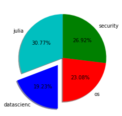

```python
#move the chart angle like [45 ,90,30]
book = ['julia','datascienc','os','security']
quintity=[8000,5000,6000,7000]
exploade = [0,0.2,0,0]
colors =['c','b','r','g']
plt.pie(quintity ,labels=book,explode=exploade,colors=colors,autopct ="%0.2f%%",shadow=True, startangle=90)
plt.show()
```

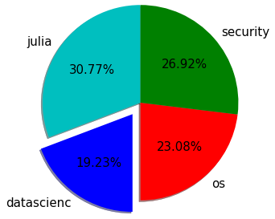

```python
#text radius means if you want to increace your size of char
book = ['julia','datascienc','os','security']
quintity=[8000,5000,6000,7000]
exploade = [0,0.2,0,0]
colors =['c','b','r','g']
textprops ={"fontsize":15}
plt.pie(quintity ,labels=book,explode=exploade,colors=colors,autopct ="%0.2f%%",shadow=True,
        startangle=90 ,textprops=textprops, radius=1.4)
plt.show()
```

# Subplots :

- The matplotlib.pyplot.subplots() method provides a way to plot multiple plots on a single figure. Given the number of rows and columns, it returns a tuple (fig, ax), giving a single figure fig with an array of axes ax. # Approach
1. Import packages
2. Import or create some data
3. Create subplot objects.
4. Draw a plot with it.

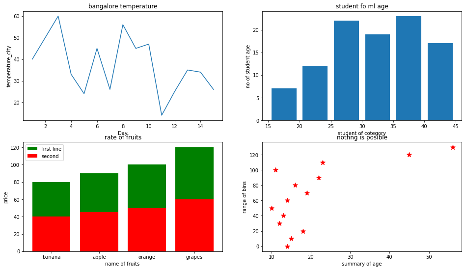

```python
# importing packages
import matplotlib.pyplot as plt
import numpy as np
plt.figure(figsize=(16,9))
# making subplots objects
plt.subplot(2,2,1)
#-------------------------------------------
#mention the title ,xlabel and ylabel
#data set
day_city = [1,2,3,4,5,6,7,8,9,10,11,12,13,14,15]
temprature_city =[40,50,60,33,24,45,26,56,45,47,14,25,35,34,26]

plt.plot(day_city,temprature_city)
plt.title("bangalore temperature")
plt.xlabel("Day")
plt.ylabel("temperature_city")
#************************************************end
plt.subplot(2,2,2)
#use bins to categorise the bar particular ways
#see the particular bar
ml_student_age = np.random.randint(18,45, (100))
py_student_age = np.random.randint(14,40, (100))
bins =[15,20,25,30,35,40,45]
plt.hist(ml_student_age,bins,rwidth=0.8)
plt.title("student fo ml age")
plt.xlabel("student of cotegory")
plt.ylabel("no of student age")
#*******************************
plt.subplot(2,2,3)
#stake bar char with multiple variable  variable
fruits =['banana','apple','orange','grapes']
price=[80,90,100,120]
less_50 =[40,45,50,60]
plt.bar(fruits,price,label ='first line',color='g')
plt.bar(fruits,less_50,label='second',color='r')
plt.xlabel('name of fruits ')
plt.ylabel('price')
plt.title('rate of fruits')
plt.legend()
plt.grid(False)
#********************************
plt.subplot(2,2,4)
#change the marker of the scatter incrage the size
population_age=[14,15,18,12,13,10,14,19,16,22,11,23,45,56]
bins =[0,10,20,30,40,50,60,70,80,90,100,110,120,130]
plt.scatter(population_age,bins ,label='skitscat',color='r', s=100, marker='*')
plt.xlabel('summary of age')
plt.ylabel('range of bins')
plt.title('nothng is posible')

plt.show()
```

# working with dataset

```python
#import libarary for Data Visualization
import matplotlib.pyplot as plt
import pandas as pd
import numpy as np
```

```python
df = pd.read_csv('C:/Users/deepak kumar/Desktop/employees.csv')
df
```

|  | First Name | Gender | Start Date | Last Login Time | Salary | Bonus % | Senior Management | Team |
| --- | --- | --- | --- | --- | --- | --- | --- | --- |
| 0 | Douglas | Male | 8/6/1993 | 12:42 PM | 97308 | 6.945 | True | Marketing |
| 1 | Thomas | Male | 3/31/1996 | 6:53 AM | 61933 | 4.170 | True | NaN |
| 2 | Maria | Female | 4/23/1993 | 11:17 AM | 130590 | 11.858 | False | Finance |
| 3 | Jerry | Male | 3/4/2005 | 1:00 PM | 138705 | 9.340 | True | Finance |
| 4 | Larry | Male | 1/24/1998 | 4:47 PM | 101004 | 1.389 | True | Client Services |
| ... | ... | ... | ... | ... | ... | ... | ... | ... |
| 995 | Henry | NaN | 11/23/2014 | 6:09 AM | 132483 | 16.655 | False | Distribution |
| 996 | Phillip | Male | 1/31/1984 | 6:30 AM | 42392 | 19.675 | False | Finance |
| 997 | Russell | Male | 5/20/2013 | 12:39 PM | 96914 | 1.421 | False | Product |
| 998 | Larry | Male | 4/20/2013 | 4:45 PM | 60500 | 11.985 | False | Business Development |
| 999 | Albert | Male | 5/15/2012 | 6:24 PM | 129949 | 10.169 | True | Sales |

1000 rows × 8 columns

```python
df.columns
```

```
Index(['First Name', 'Gender', 'Start Date', 'Last Login Time', 'Salary',
       'Bonus %', 'Senior Management', 'Team'],
      dtype='object')
```

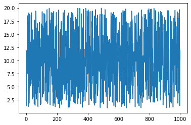

```python
#line plot
plt.plot(df['Bonus %'])
plt.show()
```

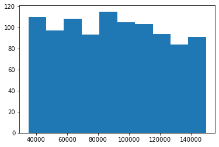

```python
plt.hist(df['Salary'])
```

```python
plt.hist(df['Salary'],bins =10)
```

[output not shown]

```python
df.columns
```

```
Index(['First Name', 'Gender', 'Start Date', 'Last Login Time', 'Salary',
       'Bonus %', 'Senior Management', 'Team'],
      dtype='object')
```